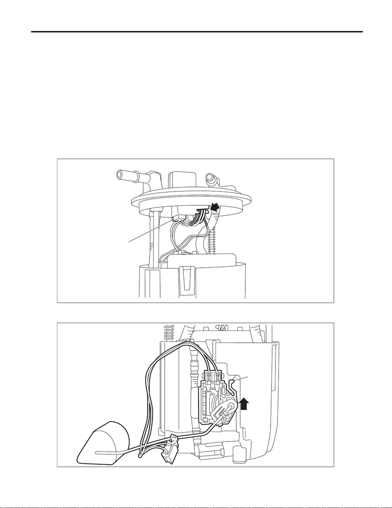

FU(w/o STI)-173

Fuel Level Sensor

FUEL INJECTION (FUEL SYSTEMS)

37.Fuel Level Sensor

A: REMOVAL

WARNING:

Place “NO OPEN FLAMES” signs near the working area.

CAUTION:

• Be careful not to spill fuel.

• If the fuel gauge indicates that two thirds or more of the fuel is remaining, be sure to drain fuel be-

fore starting work to avoid the fuel to spill.

NOTE:

The fuel level sensor is built in fuel pump assembly.

1) Remove the fuel pump assembly. <Ref. to FU(w/o STI)-168, REMOVAL, Fuel Pump.>

2) Disconnect the fuel level sensor connector (A), and pull out the connector cable and fuel level sensor har-

ness from the clip.

3) While pressing the claw (A) of the fuel level sensor, slide the fuel level sensor in the direction of the arrow,

and remove the fuel level sensor.

(A)

FU-07673

(A)

FU-07674

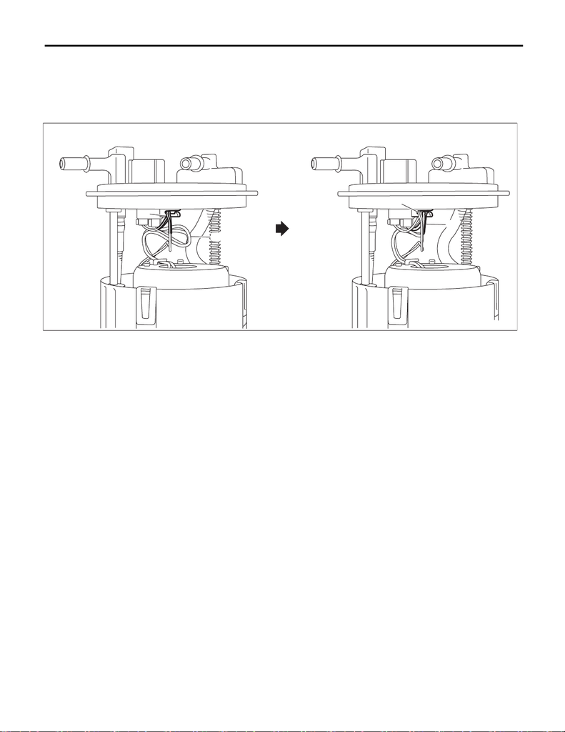

Fuel Level Sensor

FUEL INJECTION (FUEL SYSTEMS)

B: INSTALLATION

Install in the reverse order of removal.

CAUTION:

Be sure to install the fuel level sensor harness to the clip first, then install the connector cable. Oth-

erwise, malfunction may occur.

(A) Fuel level sensor harness (B) Connector cable

(A)

(B)

(A)

(B)

FU-08450

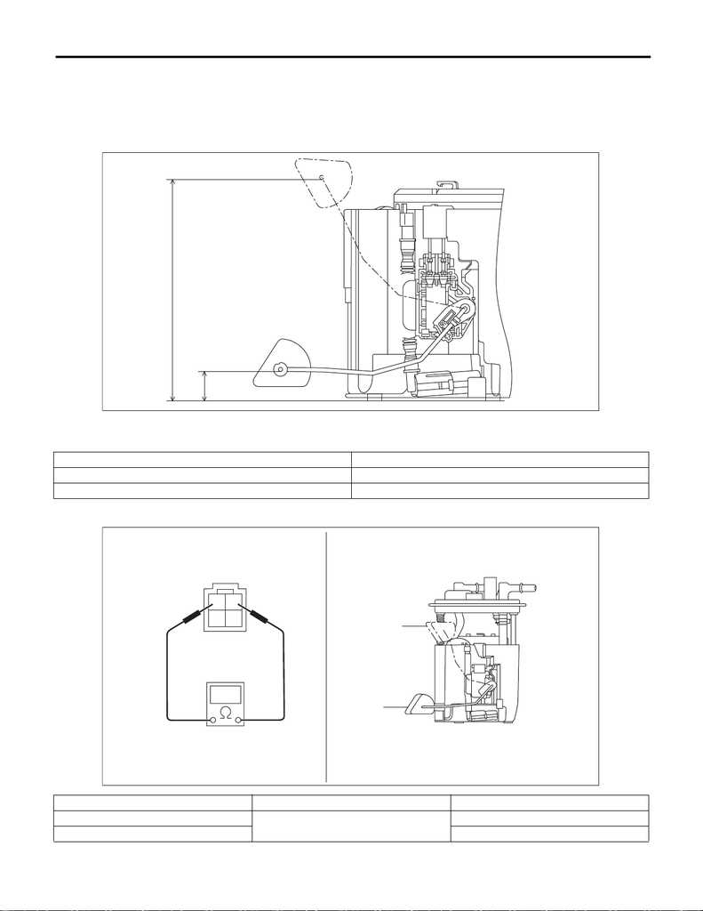

Fuel Level Sensor

FUEL INJECTION (FUEL SYSTEMS)

C: INSPECTION

1) Check that the fuel level sensor has no damage.

2) Measure the fuel level sensor float position.

NOTE:

When inspecting the fuel level sensor, perform the work with the sensor installed to the fuel pump.

3) Check the resistance between fuel level sensor terminals by the connector on top of the fuel pump.

(1) FULL (2) EMPTY (3) Fuel tank seating surface

Float position Standard

FULL to Fuel tank seating surface (A) 133.0±4 mm (5.236±0.157 in)

EMPTY to Fuel tank seating surface (B) 21.6±4 mm (0.850±0.157 in)

Float position Terminal No. Standard

FULL (A)

1 and 2

8.7±1.0 Ω

EMPTY (B) 139.1±2.0 Ω

FU-07740

(1)

(A)

(B)

(3)

(2)

FU-07676

12

43

(A)

(B)